# Markov Chain Monte Carlo I

Chelsea Parlett-Pelleriti

# Markov Chain Monte Carlo

## Motivation: Sampling from Distributions

❓how can we take random samples from this distribution?

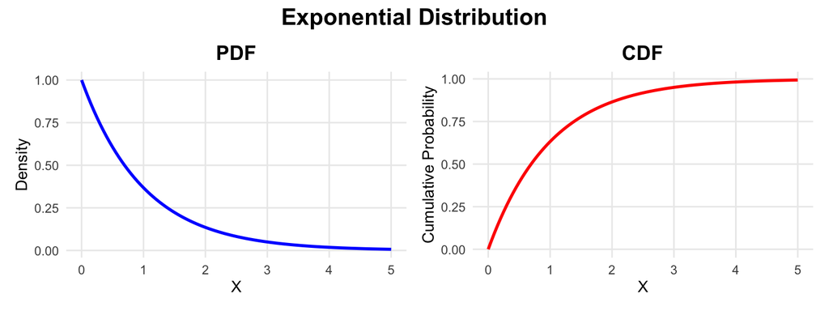

## Motivation: Sampling from Distributions

`rexp()` (or `rnorm()`, or `runif()`…)

```
 [1] 1.004726107 1.899397748 0.668582603 0.131195115 1.327563672 0.957235750
 [7] 2.569706181 0.007746431 1.859365312 0.464416840 0.256819900 0.711314304
[13] 0.331531289 0.772841139 0.716172114 0.622136481 3.282682344 2.696552707
[19] 0.410249213 0.062705896
```

## `rexp()`: Inverse Transform Sampling

💡 Let’s take something **easy** (like a uniform distribution $U$) to sample and use it to sample from our distribution $f(x)$!

## `rexp()`: Inverse Transform Sampling

$$CDF_{\mathcal{exp}} = P(X \leq x) = \int_0^x e^{-t} \, dt$$

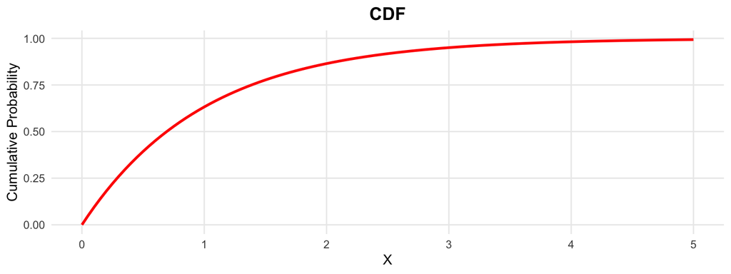

## `rexp()`: Inverse Transform Sampling

Claim: $F^{-1}(U) = X$

(in english: the inverse CDF ($F^{-1}(x)$) applied to a uniform distribution ($U$) will give us samples from the PDF $X \sim \pi(x)$)

- $U \sim Uniform(0,1)$
- $F(x) = \text{CDF}$
- $F^{-1}(x) = \text{inverse CDF}$

## `rexp()`: Inverse Transform Sampling

Proof:

$$F(x) = P(X \leq x) = \\ P(T(U) \leq x) = \\ P(U \leq T^{-1}(x)) = \\ T^{-1}(x) \\ \text{ and } T(x) = F^{-1}(x)$$

1. Definition of CDF
2. Replace $X$ with some function $T(U)$ which transforms uniforms into $X$
3. Apply $T^{-1}$ to both sides of ineq.
4. For $U$, $P(U \leq x)$ is $x$ (think: what is $P(U \leq 0.5)$)
5. Invert both sides

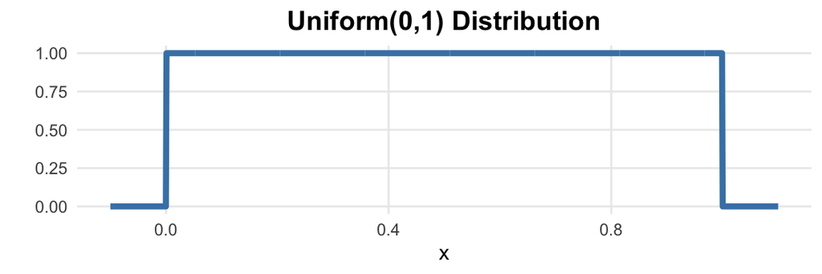

## Motivation: Sampling from Distributions

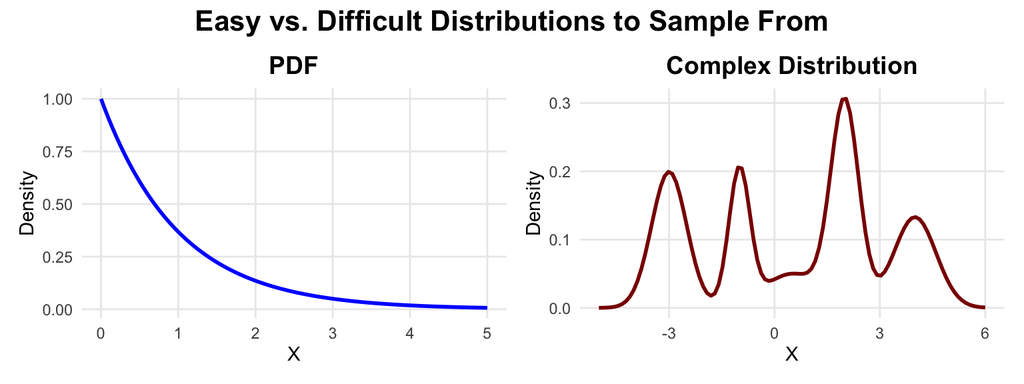

# 🎰 Monte Carlo Methods

## $\pi$ Monte Carlo

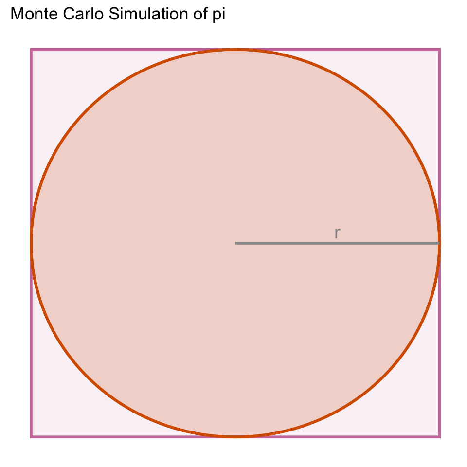

$$\text{area of square} = (2r)^2 = 4r^2 \\
\text{area of circle} = \pi r^2 \\
\frac{\text{area of circle}}{
\text{area of square}} = \frac{\pi}{4}$$

## $\pi$ Monte Carlo

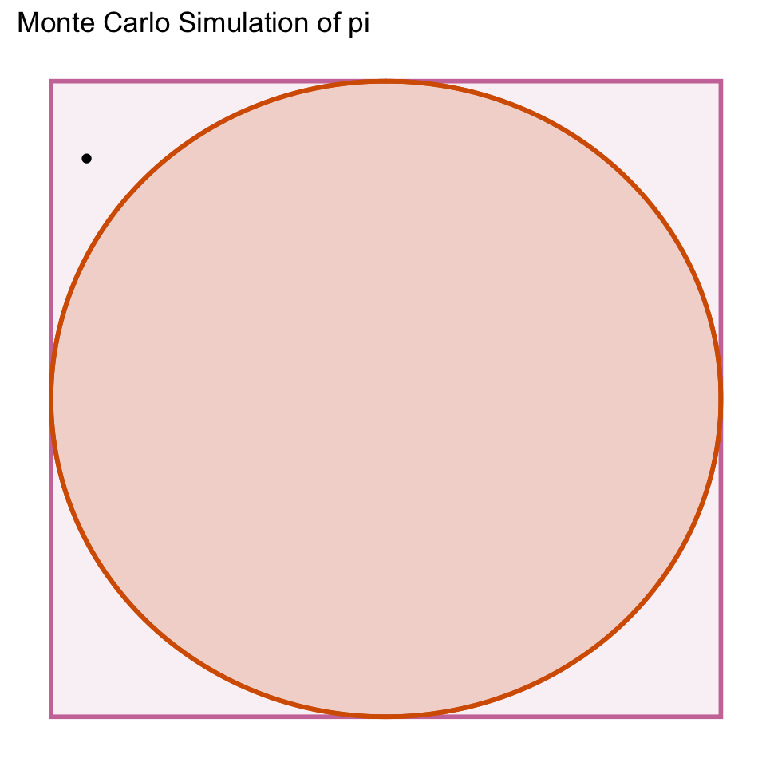

## $\pi$ Monte Carlo

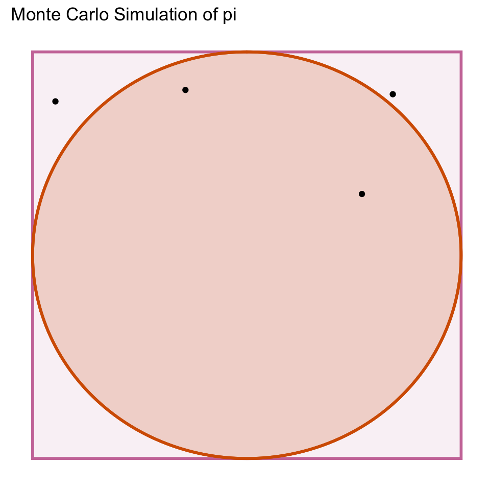

## $\pi$ Monte Carlo

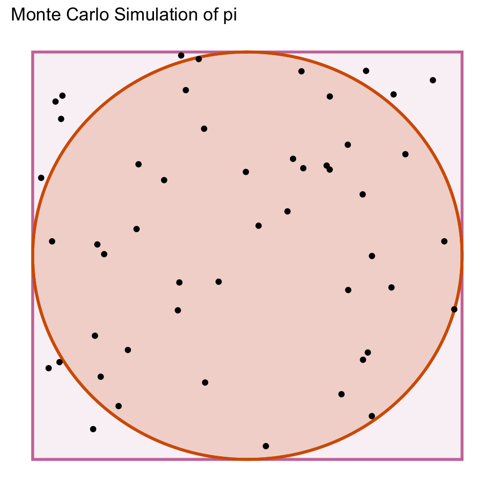

## $\pi$ Monte Carlo

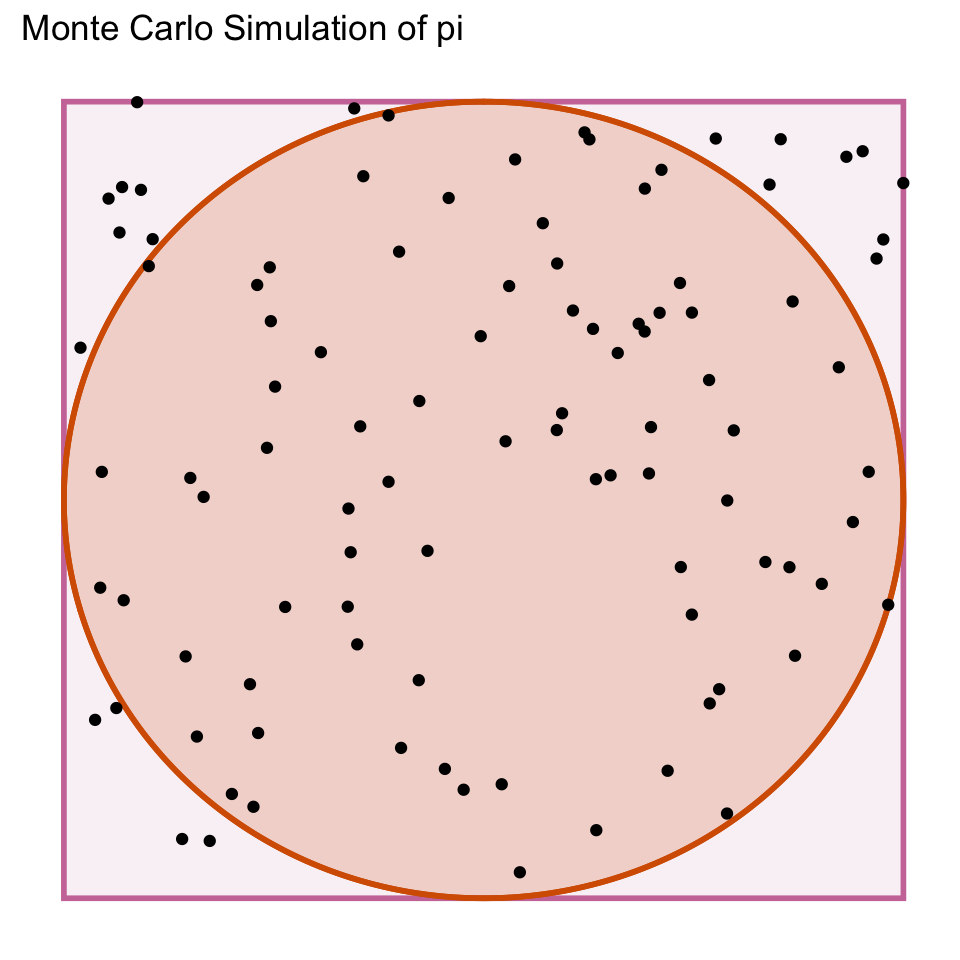

## $\pi$ Monte Carlo

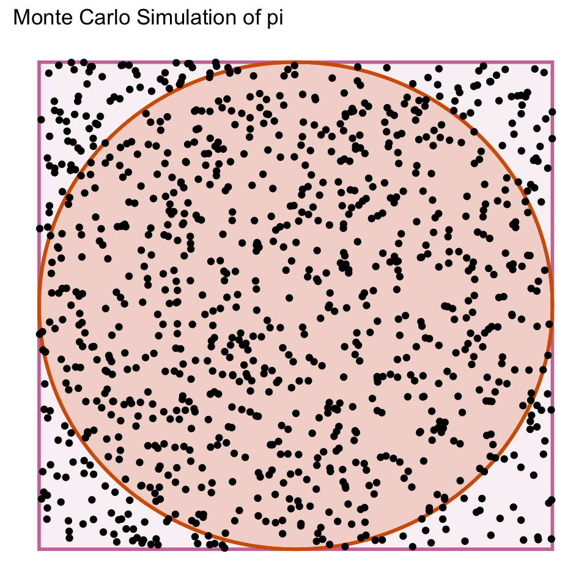

```r
# simulate data
set.seed(540)
x <- runif(1000,0,1)
y <- runif(1000,0,1)
df <- data.frame(x,y)

# check if dots are inside circle
df$in_circle <- sqrt((df$x - 0.5)^2 +
                       (df$y - 0.5)^2) <= 0.5
print(paste("sim   : ", mean(df$in_circle)))
```

```
[1] "sim   :  0.777"
```

```r
print(paste0("actual: ", round(pi/4,3)))
```

```
[1] "actual: 0.785"
```

## $\pi$ Monte Carlo

[figure not shown]

## Two-in-a-row

I roll a die, only stop if I get same number twice in a row.

❓ What is $\mathbb{E}(\text{# of die rolls})$?

## Two-in-a-row

- $S_0$: haven’t rolled yet
- $S_1$: we haven’t gotten 2-in-a-row yet, but we’ve rolled
- $S_2$: last two rolls are the same! win!

$$\mathbb{E}_0 = \underbrace{1}_\text{first roll} + \mathbb{E}_1$$

$$\mathbb{E}_1 = \underbrace{\frac{1}{6}(1)}_\text{matched last roll} + \underbrace{\frac{5}{6} (1 + \mathbb{E}_1)}_\text{didn't} \\
\mathbb{E}_1 - \frac{5}{6}\mathbb{E}_1 = \frac{1}{6} + \frac{5}{6} \\
\frac{1}{6}\mathbb{E}_1 = 1 \\
\mathbb{E}_1 = 6 \\
\mathbb{E}_0 = 1 + \mathbb{E}_1 = 7$$

## Two-in-a-row

```r
n_sim <- 1000
sim_game <- function(sides = 6){
  won <- FALSE
  last_roll <- 999
  n_rolls <- 0
  while(!won){
    roll <- sample(1:6, size = 1) # die roll
    n_rolls <- n_rolls + 1
    if (roll == last_roll){
      return(n_rolls)
    } else {
      last_roll <- roll
    }
  }
}
out <- sapply(1:n_sim, function(x) sim_game())
mean(out)
```

```
[1] 7.27
```

## Advantages/Disadvantages

### Advantages

- “Easy”
- Sometimes Fast

### Disadvantages

- Not always fast
- Not always exact

# Markov Chains

## Markov Process Definition

Graph of states + transitions.

**Markov Property**: Future state depends **only** on current state (efficient…but can cause problems)

$$P(X_n = x | X_1 = x_1, X_2 = x_2, ..., X_{n-1}= x_{n-1}) = P(X_n = x | X_{n-1}= x_{n-1})$$

## Markov Transition Matrices

A **steady state** or **stationary distribution** occurs when $xA = x$.

## Markov Transition Matrices

$$A = \begin{bmatrix}
0.2 & 0.6 & 0.2 \\
0.3 & 0 & 0.7 \\
0.5 & 0 & 0.5
\end{bmatrix}$$

$$A^T = \begin{bmatrix}
0.2 & 0.3 & 0.5 \\
0.6 & 0 & 0 \\
0.2 & 0.7 & 0.5
\end{bmatrix}$$

```r
# burger, pizza, hotdog
tr <- matrix(c(0.2, 0.6, 0.2,
               0.3,0,0.7,
               0.5,0,0.5), ncol = 3)
eigen(tr)$vectors[,1]/sum(eigen(tr)$vectors[,1])
```

```
[1] 0.3521127+0i 0.2112676+0i 0.4366197+0i
```

## Markov Transition Matrices

#### Detailed Balance Condition

$$p(x)T(y|x) = p(y)T(x|y) \,\,\, \forall_{x,y} \Rightarrow \\
\sum_{x}p(x)T(y|x) = p(y)\sum_{x}T(x|y) = p(y) \Rightarrow \\
\underbrace{\sum_{x}p(x)T(y|x)}_\text{flowing into y} = \underbrace{p(y)}_\text{what's in y} \Rightarrow \\
pT = p$$

## Markov Chain Properties

- **Markov Property:** state only relies on last state
- $\sum_{i=0}^n p_i = 1$

## Markov Seuss

[figure not shown]

# Markov Chain Monte Carlo

## Accept/Reject Sampling

**Problem**: sample from $f(x)$, but don’t have PDF/CDF, only know it’s shape $p(x)$

$$p(x) \propto f(x)$$

**Solution**: sample from $g(x)$ and only accept samples according to how likely they are in $p(x)$

## Accept/Reject Sampling

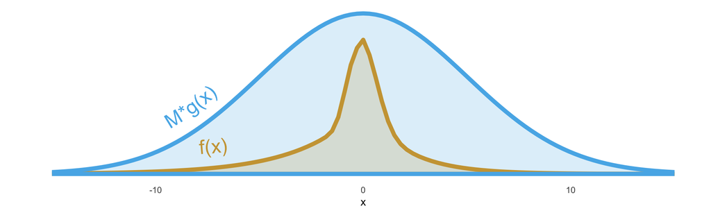

- sample from $g(x)$
- accept with prob $\frac{f(x)}{M*g(x)}$

## Accept/Reject Sampling

Proof:

$$D(x | A) = \frac{P(A|x)D(x)}{P(A)} =
\frac{\frac{f(x)}{M*g(x)} g(x)}{P(A)}\\
P(A) = \int g(x) \frac{f(x)}{M*g(x)} dx = \frac{1}{M} \int f(x)dx = \frac{NC}{M} \\
D(x | A) = \frac{f(x)/M}{NC/M} = \frac{f(x)}{NC} = p(x)$$

## Accept/Reject Sampling

**Cons**: samples are uncorrelated, we throw away information about a good value we find, can be inefficient. Hard to choose $g(x)$

**Enter** MCMC! 💡 Next sample depends on previous sample.

## Markov Chain Monte Carlo

**Markov Chain**: we’re using a markov process to generate proposed samples

**Monte Carlo**: we’re drawing random samples to estimate a distribution

## Markov Chain Monte Carlo

We want a markov chain whose *steady state* is the distribution $f(x)$.

❓ Do MPs converge to their steady state right away?

## Markov Chain Monte Carlo

**Goal**: find a markov chain whose steady state (after a burn-in period) is $p(x)$

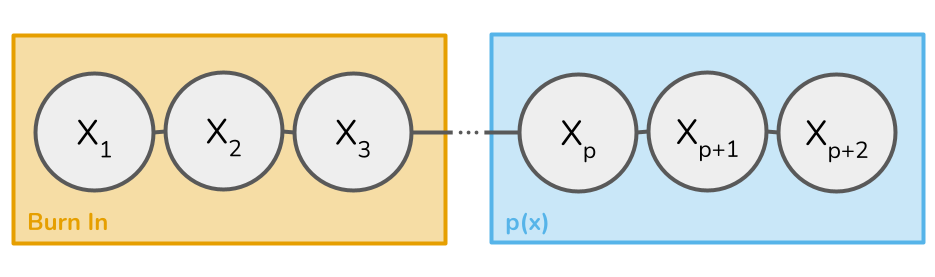

## King Markov

👑 King Markov wants to visit his **5 islands** with populations 100, 200, 300, 400, 500

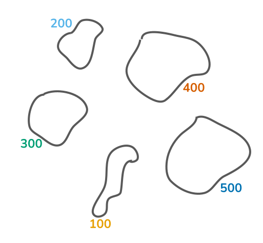

Metropolis Islands

## King Markov

Requirements:

- visit islands proportional to population
- no tracking islands/populations over time
- randomness/spontaneity of visits

❓ How

## King Markov

#### Proposal:

1. Randomly choose an island using $J \left (\color{blue}{\text{island}_n} | \color{red}{\text{island}_{n-1}}\right )$
2. Send scout to $\color{blue}{\text{island}_n}$
3. Ask for $\color{blue}{\text{island}_n}$ population
4. Go to $\color{blue}{\text{island}_n}$ with probability $A$, stay at $\color{red}{\text{island}_{n-1}}$ with probability $1-A$

💡 How would you choose $J$ and $A$?

## King Markov

- $J$: any random process where $J(a | b) = J(b | a)$
- $A$: $min \left (1,\frac{pop(\color{blue}{\text{island}_n})}{pop(\color{red}{\text{island}_{n-1}})} \right )$

## King Markov

```r
markov_step <- function(island){
  islands <- LETTERS[1:5]
  islands_pop <- list(A = 100,
                      B = 200,
                      C = 300,
                      D = 400,
                      E = 500)

  proposed_i <- sample(islands[islands != island],
                       size = 1)

  accept_prob <- min(1,
                islands_pop[[proposed_i]]/islands_pop[[island]])

  u <- runif(1)
  accepted <-  u <= accept_prob
  value <- ifelse(accepted,
                  proposed_i,
                  island)

  value

}

markov_step("A")
```

```
[1] "C"
```

## King Markov

```r
n_sim <- 10000
isl = "A"
track <- c(isl)

for (i in 1:n_sim){
  isl <- markov_step(isl)
  track <- c(track, isl)
}

ggplot(data = data.frame(track),
       aes(x = track, fill = track)) +
  geom_bar(color = "black") +
  theme_minimal() +
  theme(panel.grid = element_blank(),
        legend.position = "none") +
  labs(x = "Island",
       y = "Nights Spent")
```

## King Markov

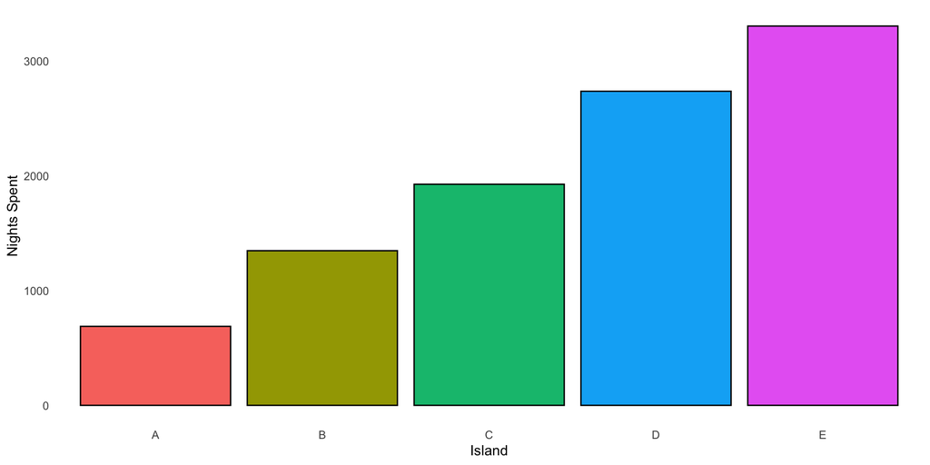

## King Markov

### Vocabulary:

- **chain**: sequence of draws from a distribution
- **markov chain**: the next state in the chain depends only on previous state
- **draw**: one sample/state from the chain

## Metropolis-Hastings

$$A(x_n \rightarrow x_*) = min \left (1, \frac{f(x_*)}{f(x_n)} \times \frac{q(x_n | x_*)}{q(x_* | x_n)} \right )$$

$\frac{q(x_n | x_*)}{q(x_* | x_n)}$ corrects for *bias* in which values the proposal distribution will generate.

when $q(x_n | x_*) >q(x_* | x_n)$ the correction makes us *more* likely to go to $x_*$

## Metropolis-Hastings

$$A(x_n \rightarrow x_*) = min \left (1, \frac{f(x_*)}{f(x_n)} \times \frac{q(x_n | x_*)}{q(x_* | x_n)} \right )$$

$\frac{q(x_n | x_*)}{q(x_* | x_n)}$ corrects for bias in which values the proposal distribution will generate.

When $q(x_n | x_*) = q(x_* | x_n)$ the correction goes away, leaving us with King Markov’s method (**Metropolis Algorithm**).

## Metropolis-Hastings

$q(x_n | x_*) = q(x_* | x_n)$

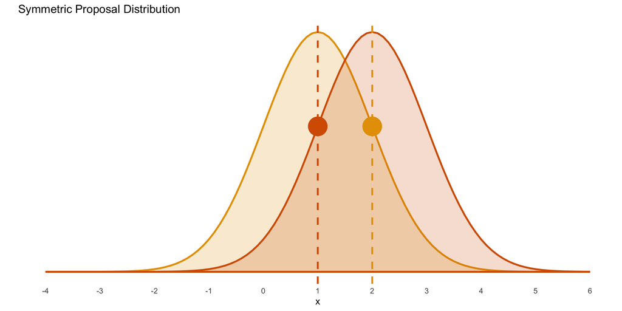

## Metropolis-Hastings

$q(x_n | x_*) \neq q(x_* | x_n)$

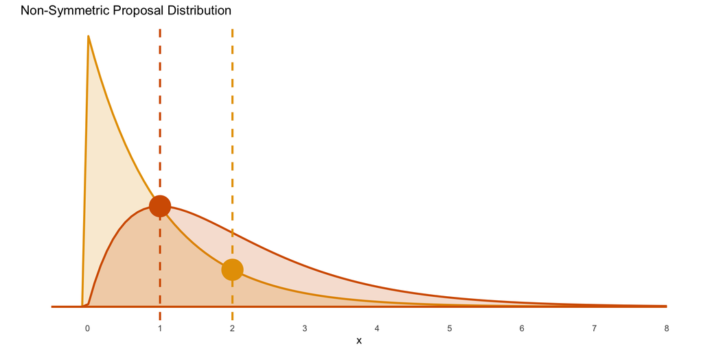

## Metropolis-Hastings

```r
metropolis_step <- function(x, sigma) {
  # generate proposal
  proposed_x <- rnorm(1, mean = x, sd = sigma)

  # calculate A
  accept_prob <- min(1, target(proposed_x) / target(x))

  # accept/reject
  accepted <- runif(1) <= accept_prob
  value <- ifelse(accepted,
                  proposed_x,
                  x)

  value
}
```

**1**

Generate proposed value using a N(x,sigma)

**2**

Calculate the probability of accepting proposal

**3**

Accept or Reject proposal

code adapted from: Navarro, Danielle. 2023. “The Metropolis-Hastings Algorithm.” April 12, 2023. https://blog.djnavarro.net/posts/2023-04-12_metropolis-hastings/.

## Peek at Future

Tons of new MCMC algorithms. But the cool ones use *gradients* to choose samples.